# Health Product User Analaysis

```r
# Remove all objects
rm(list=ls(all=TRUE))

# Load packages
library(tidyverse); library(dplyr); library(ggplot2)

# install.packages('gridExtra')
library(gridExtra)
```

## 1. Load and inspect data

### Overview:

A set of Fitbit’s public data set is used to gain insights of how users use the health products. Here, only “daily” records will be used to get an overall understanding of usage throughout the day.

### Dataset:

- `<<dailyActivity_merged.csv>>`: calories, intensities, steps information
- `<<sleepDay_merged.csv>>`: sleep information
- `<<weightLogInfo_merged.csv>>`: useful but will not be used because it is limited the sample size is not sufficient (8/33 users) to draw a general conclusion

```r
# Load data
df.activity = read.csv('Data/dailyActivity_merged.csv')
df.sleep = read.csv('Data/sleepDay_merged.csv')
```

```r
# Inspect data
head(df.activity)
```

|  | Id | ActivityDate | TotalSteps | TotalDistance | TrackerDistance | LoggedActivitiesDistance | VeryActiveDistance | ModeratelyActiveDistance | LightActiveDistance | SedentaryActiveDistance | VeryActiveMinutes | FairlyActiveMinutes | LightlyActiveMinutes | SedentaryMinutes | Calories |
| --- | --- | --- | --- | --- | --- | --- | --- | --- | --- | --- | --- | --- | --- | --- | --- |
| 1 | 1503960366 | 4/12/2016 | 13162 | 8.50 | 8.50 | 0 | 1.88 | 0.55 | 6.06 | 0 | 25 | 13 | 328 | 728 | 1985 |
| 2 | 1503960366 | 4/13/2016 | 10735 | 6.97 | 6.97 | 0 | 1.57 | 0.69 | 4.71 | 0 | 21 | 19 | 217 | 776 | 1797 |
| 3 | 1503960366 | 4/14/2016 | 10460 | 6.74 | 6.74 | 0 | 2.44 | 0.40 | 3.91 | 0 | 30 | 11 | 181 | 1218 | 1776 |
| 4 | 1503960366 | 4/15/2016 | 9762 | 6.28 | 6.28 | 0 | 2.14 | 1.26 | 2.83 | 0 | 29 | 34 | 209 | 726 | 1745 |
| 5 | 1503960366 | 4/16/2016 | 12669 | 8.16 | 8.16 | 0 | 2.71 | 0.41 | 5.04 | 0 | 36 | 10 | 221 | 773 | 1863 |
| 6 | 1503960366 | 4/17/2016 | 9705 | 6.48 | 6.48 | 0 | 3.19 | 0.78 | 2.51 | 0 | 38 | 20 | 164 | 539 | 1728 |

```r
head(df.sleep)
```

|  | Id | SleepDay | TotalSleepRecords | TotalMinutesAsleep | TotalTimeInBed |
| --- | --- | --- | --- | --- | --- |
| 1 | 1503960366 | 4/12/2016 12:00:00 AM | 1 | 327 | 346 |
| 2 | 1503960366 | 4/13/2016 12:00:00 AM | 2 | 384 | 407 |
| 3 | 1503960366 | 4/15/2016 12:00:00 AM | 1 | 412 | 442 |
| 4 | 1503960366 | 4/16/2016 12:00:00 AM | 2 | 340 | 367 |
| 5 | 1503960366 | 4/17/2016 12:00:00 AM | 1 | 700 | 712 |
| 6 | 1503960366 | 4/19/2016 12:00:00 AM | 1 | 304 | 320 |

```r
# Inspect unique ids
n_unique = function (series) {
  length(unique(series))
}
n_unique(df.activity$Id) # 33/33
```

```
[1] 33
```

```r
n_unique(df.sleep$Id) # 24/33 -  some missing values found
```

```
[1] 24
```

## 2. Clean data

```r
# Unify common column names (id, date) before merging
df.activity = rename(df.activity, Date=ActivityDate)
df.sleep = rename(df.sleep, Date=SleepDay)

# Convert into date object
df.activity$Date = as.Date(df.activity$Date, format='%m/%d/%Y') # date string -> date
df.sleep$Date = as.Date(df.sleep$Date, format='%m/%d/%Y') # datetime string -> date
```

```r
# Make sure all records are unique by Id and Date(daily)
df.activity %>% duplicated() %>% sum() # no duplicated field
```

```
[1] 0
```

```r
df.sleep %>% duplicated() %>% sum() # 3 duplicated fields
```

```
[1] 3
```

```r
# Inspect duplication in 'df.sleep'
df.sleep[duplicated(df.sleep[,1:2]), c('Id', 'Date')]
```

|  | Id | Date |
| --- | --- | --- |
| 162 | 4388161847 | 2016-05-05 |
| 224 | 4702921684 | 2016-05-07 |
| 381 | 8378563200 | 2016-04-25 |

```r
# Further inspection of the three duplicated records
df.sleep[which(df.sleep$Id == 4388161847 & df.sleep$Date == '2016-05-05'), ]
```

|  | Id | Date | TotalSleepRecords | TotalMinutesAsleep | TotalTimeInBed |
| --- | --- | --- | --- | --- | --- |
| 161 | 4388161847 | 2016-05-05 | 1 | 471 | 495 |
| 162 | 4388161847 | 2016-05-05 | 1 | 471 | 495 |

```r
df.sleep[which(df.sleep$Id == 4702921684 & df.sleep$Date == '2016-05-07'), ]
```

|  | Id | Date | TotalSleepRecords | TotalMinutesAsleep | TotalTimeInBed |
| --- | --- | --- | --- | --- | --- |
| 223 | 4702921684 | 2016-05-07 | 1 | 520 | 543 |
| 224 | 4702921684 | 2016-05-07 | 1 | 520 | 543 |

```r
df.sleep[which(df.sleep$Id == 8378563200 & df.sleep$Date == '2016-04-25'), ]
```

|  | Id | Date | TotalSleepRecords | TotalMinutesAsleep | TotalTimeInBed |
| --- | --- | --- | --- | --- | --- |
| 380 | 8378563200 | 2016-04-25 | 1 | 388 | 402 |
| 381 | 8378563200 | 2016-04-25 | 1 | 388 | 402 |

```r
# Remove duplicates records as they are identical
# dim(df.sleep) # before removal 413 x 5
df.sleep = df.sleep[!duplicated(df.sleep[, 1:2]), ]
dim(df.sleep) # after removal 410 x 5
```

```
[1] 410   5
```

```r
# Merge data frames into a master dataframe 'df'
df = merge(df.activity, df.sleep, all.x=TRUE, by.x=c('Id','Date'))

# view(df)
str(df) # remember there are some missing data from sleep data
```

```
'data.frame':   940 obs. of  18 variables:
 $ Id                      : num  1.5e+09 1.5e+09 1.5e+09 1.5e+09 1.5e+09 ...
 $ Date                    : Date, format: "2016-04-12" "2016-04-13" ...
 $ TotalSteps              : int  13162 10735 10460 9762 12669 9705 13019 15506 10544 9819 ...
 $ TotalDistance           : num  8.5 6.97 6.74 6.28 8.16 ...
 $ TrackerDistance         : num  8.5 6.97 6.74 6.28 8.16 ...
 $ LoggedActivitiesDistance: num  0 0 0 0 0 0 0 0 0 0 ...
 $ VeryActiveDistance      : num  1.88 1.57 2.44 2.14 2.71 ...
 $ ModeratelyActiveDistance: num  0.55 0.69 0.4 1.26 0.41 ...
 $ LightActiveDistance     : num  6.06 4.71 3.91 2.83 5.04 ...
 $ SedentaryActiveDistance : num  0 0 0 0 0 0 0 0 0 0 ...
 $ VeryActiveMinutes       : int  25 21 30 29 36 38 42 50 28 19 ...
 $ FairlyActiveMinutes     : int  13 19 11 34 10 20 16 31 12 8 ...
 $ LightlyActiveMinutes    : int  328 217 181 209 221 164 233 264 205 211 ...
 $ SedentaryMinutes        : int  728 776 1218 726 773 539 1149 775 818 838 ...
 $ Calories                : int  1985 1797 1776 1745 1863 1728 1921 2035 1786 1775 ...
 $ TotalSleepRecords       : int  1 2 NA 1 2 1 NA 1 1 1 ...
 $ TotalMinutesAsleep      : int  327 384 NA 412 340 700 NA 304 360 325 ...
 $ TotalTimeInBed          : int  346 407 NA 442 367 712 NA 320 377 364 ...
```

## 3. Exploratory analysis

### Question1: How many steps would be required to burn 100 calories?

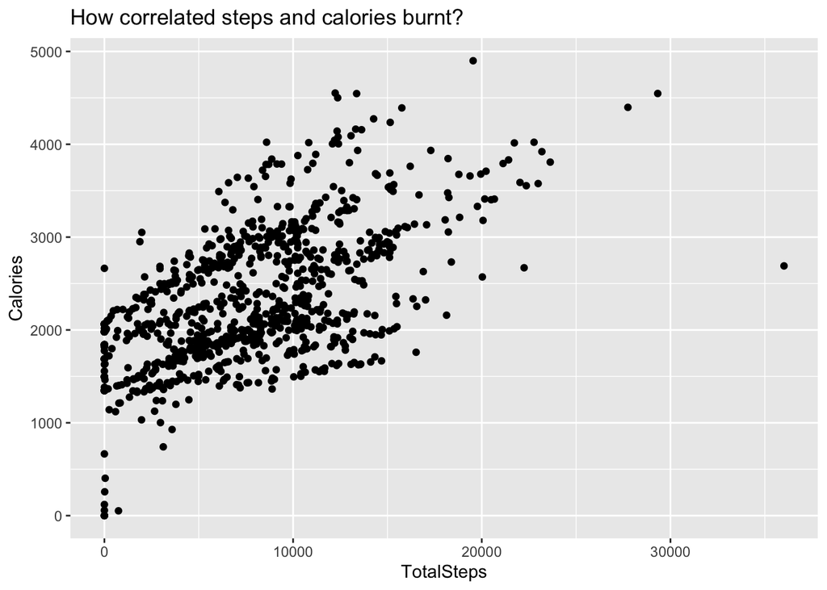

```r
# Scatter plot to visualize relationships
df %>%
  select(c('TotalSteps', 'Calories')) %>%
  drop_na() %>%
  ggplot(aes(x=TotalSteps, y=Calories)) + geom_point() + labs(title='How correlated steps and calories burnt?')
```

```r
df %>% select(c(TotalSteps, TotalDistance, Calories)) %>% cor()
```

```
              TotalSteps TotalDistance  Calories
TotalSteps     1.0000000     0.9853688 0.5915681
TotalDistance  0.9853688     1.0000000 0.6449619
Calories       0.5915681     0.6449619 1.0000000
```

There is moderately positive correlation between steps and calories. It is obvious that steps and distance are highly correlated.

```r
# Using linear regression
# One particular outlier found deviating the trend - so remove steps > 30000
df %>%
  filter(TotalSteps<30000) %>%
  drop_na() %>%
  lm(formula=Calories~TotalSteps) %>%
  summary()
```

```
Call:
lm(formula = Calories ~ TotalSteps, data = .)

Residuals:
     Min       1Q   Median       3Q      Max
-1502.41  -567.18   -18.76   565.53  1887.26

Coefficients:
             Estimate Std. Error t value Pr(>|t|)
(Intercept) 1.758e+03  7.818e+01  22.488   <2e-16 ***
TotalSteps  7.412e-02  8.253e-03   8.982   <2e-16 ***
---
Signif. codes:  0 '***' 0.001 '**' 0.01 '*' 0.05 '.' 0.1 ' ' 1

Residual standard error: 693.9 on 408 degrees of freedom
Multiple R-squared:  0.1651,    Adjusted R-squared:  0.163
F-statistic: 80.67 on 1 and 408 DF,  p-value: < 2.2e-16
```

### Question2: Does degree of activities/distance influence calories burnt?

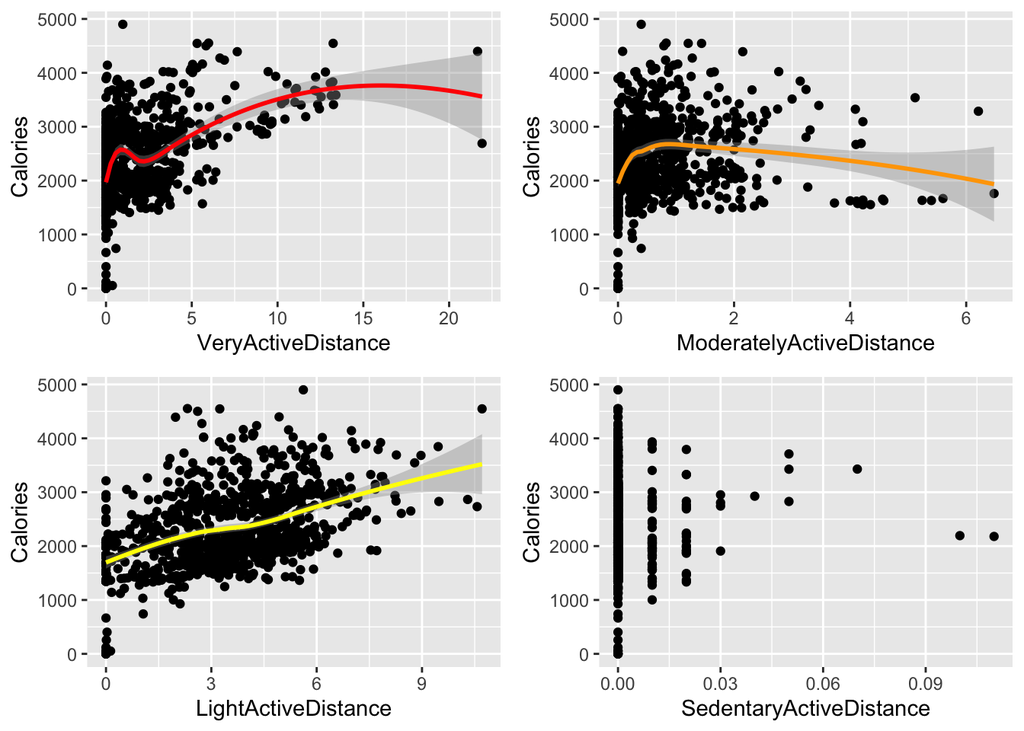

```r
# Plot the relationship between distances of 4 different activity types and calories
# f1. calories vs very active distance
f1 = ggplot(df, aes(x=VeryActiveDistance, y=Calories)) +
  geom_point(color='black') +
  geom_smooth(formula=y~x, method='loess', color='red')

# f2. calories vs moderately active distance
f2 = ggplot(df, aes(x=ModeratelyActiveDistance, y=Calories)) +
  geom_point(color='black') +
  geom_smooth(formula=y~x, method='loess', color='orange')

# f3. calories vs lightly active distance
f3 = ggplot(df, aes(x=LightActiveDistance, y=Calories)) +
  geom_point(color='black') +
  geom_smooth(formula=y~x, method='loess', color='yellow')

# f4. calories vs sedentary distance
f4 = ggplot(df, aes(x=SedentaryActiveDistance, y=Calories)) +
  geom_point(color='black') +
  geom_smooth(formula=y~x, method='loess', color='green')

# Combine plots
grid.arrange(f1, f2, f3, f4, nrow=2)
```

There is a negative trend between `moderately active distance` and `calories burnt`, which is not intuitive. Seeing the graph, this trend is resulted by some outliers (more than 3.5 KM over 1500-2000 calories burnt). It may be worth checking what they are - in the following section.

On the other hand, trend is not obvious between `sedentary active distance` and `calories burnt` very likely due to high concentration of zero values (no sedentary activity).

Let’s plot the minutes vs calories to see if the trend draws the similar trend lines.

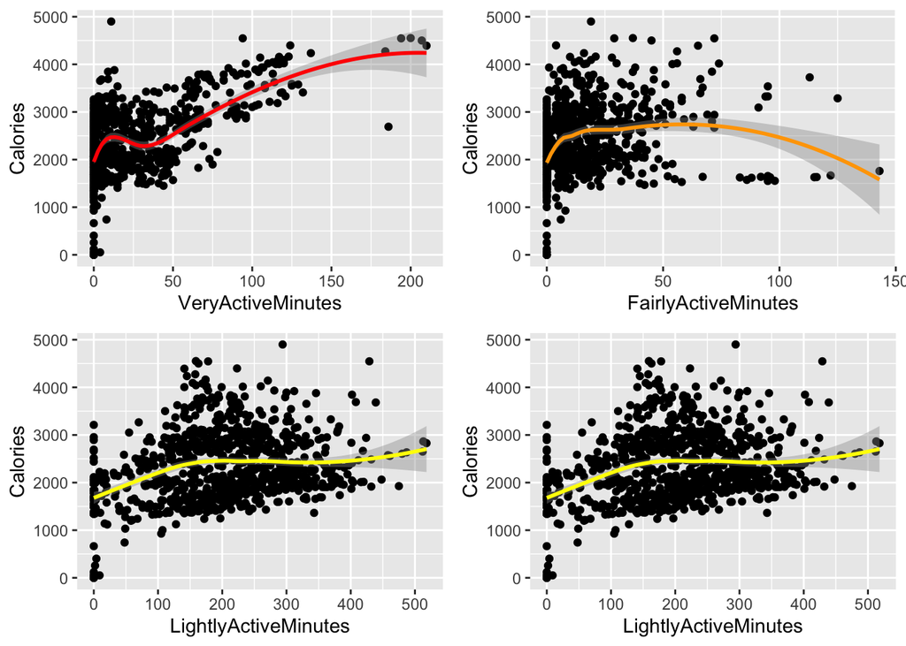

```r
# Plot the relationship between minutes of 4 different activity types and calories
# f1. calories vs very active minutes
f1 = ggplot(df, aes(x=VeryActiveMinutes, y=Calories)) +
  geom_point(color='black') +
  geom_smooth(formula=y~x, method='loess', color='red')

# f2. calories vs fairly active minutes
f2 = ggplot(df, aes(x=FairlyActiveMinutes, y=Calories)) +
  geom_point(color='black') +
  geom_smooth(formula=y~x, method='loess', color='orange')

# f3. calories vs lightly active minutes
f3 = ggplot(df, aes(x=LightlyActiveMinutes, y=Calories)) +
  geom_point(color='black') +
  geom_smooth(formula=y~x, method='loess', color='yellow')

# f4. calories vs sedentary minutes
f4 = ggplot(df, aes(x=SedentaryMinutes, y=Calories)) +
  geom_point(color='black') +
  geom_smooth(formula=y~x, method='loess', color='green')

# Combine plots
grid.arrange(f1, f2, f3, f3, nrow=2)
```

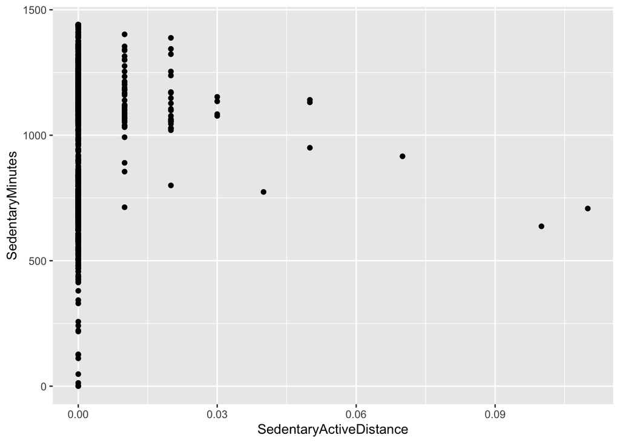

```r
# It should have a positive linear trend, or there is something wrong
df %>% ggplot(aes(x=SedentaryActiveDistance, y=SedentaryMinutes)) + geom_point()
```

The graph clearly shows that the device captured minute records up to 1500 minutes despite zero distance recorded. Those records account for 91.3% of the total records, which is seriously wrong. It makes more sense that we use minutes variables instead of distance variables.

```r
df %>% filter(SedentaryActiveDistance==0) %>% nrow() / nrow(df)
```

```
[1] 0.912766
```

Let’s now inspect outliers that make moderate active vs calories negative trend. Outliers is characterized more than 75 minutes moderate(fairly) active over 1500-2000 calories burnt.

```r
df %>% filter(FairlyActiveMinutes>75 & Calories > 1500 & Calories < 2000) # 13 records
```

| Id | Date | TotalSteps | TotalDistance | TrackerDistance | LoggedActivitiesDistance | VeryActiveDistance | ModeratelyActiveDistance | LightActiveDistance | SedentaryActiveDistance | VeryActiveMinutes | FairlyActiveMinutes | LightlyActiveMinutes | SedentaryMinutes | Calories | TotalSleepRecords | TotalMinutesAsleep | TotalTimeInBed |
| --- | --- | --- | --- | --- | --- | --- | --- | --- | --- | --- | --- | --- | --- | --- | --- | --- | --- |
| 3977333714 | 2016-04-16 | 13459 | 9.00 | 9.00 | 0 | 2.03 | 4.00 | 2.97 | 0 | 31 | 83 | 153 | 663 | 1625 | 1 | 283 | 510 |
| 3977333714 | 2016-04-18 | 11663 | 7.80 | 7.80 | 0 | 0.25 | 3.73 | 3.82 | 0 | 4 | 95 | 214 | 605 | 1584 | 2 | 412 | 522 |
| 3977333714 | 2016-04-20 | 11658 | 7.83 | 7.83 | 0 | 0.20 | 4.35 | 3.28 | 0 | 2 | 98 | 164 | 845 | 1554 | 2 | 152 | 305 |
| 3977333714 | 2016-04-23 | 12058 | 8.07 | 8.07 | 0 | 0.00 | 4.22 | 3.85 | 0 | 0 | 92 | 252 | 724 | 1638 | 1 | 235 | 372 |
| 3977333714 | 2016-04-24 | 14112 | 10.00 | 10.00 | 0 | 3.27 | 4.56 | 2.17 | 0 | 30 | 95 | 129 | 660 | 1655 | 1 | 310 | 526 |
| 3977333714 | 2016-04-26 | 11388 | 7.62 | 7.62 | 0 | 0.45 | 4.22 | 2.95 | 0 | 7 | 95 | 170 | 797 | 1551 | 1 | 250 | 371 |
| 3977333714 | 2016-05-02 | 16520 | 11.05 | 11.05 | 0 | 1.54 | 6.48 | 3.02 | 0 | 24 | 143 | 176 | 713 | 1760 | 1 | 230 | 384 |
| 3977333714 | 2016-05-04 | 13559 | 9.44 | 9.44 | 0 | 1.81 | 4.58 | 2.89 | 0 | 14 | 96 | 142 | 852 | 1628 | 1 | 213 | 336 |
| 3977333714 | 2016-05-05 | 12312 | 8.58 | 8.58 | 0 | 1.76 | 4.11 | 2.71 | 0 | 14 | 88 | 178 | 680 | 1618 | 1 | 318 | 480 |
| 3977333714 | 2016-05-07 | 11550 | 7.73 | 7.73 | 0 | 0.00 | 4.13 | 3.59 | 0 | 0 | 86 | 208 | 703 | 1574 | 1 | 237 | 443 |

[output cut: 3 more lines]

It appears that the outliers are from 13 records from one particular user with the id #3977333714. Let’s inspect this person.

```r
df %>% filter(Id == 3977333714) %>%
  select(c(1, 3, 4, 11: ncol(df))) %>%
  summary()
```

```
       Id              TotalSteps    TotalDistance    VeryActiveMinutes
 Min.   :3.977e+09   Min.   :  746   Min.   : 0.500   Min.   : 0.00
 1st Qu.:3.977e+09   1st Qu.: 9266   1st Qu.: 6.223   1st Qu.: 4.25
 Median :3.977e+09   Median :11604   Median : 7.815   Median :14.50
 Mean   :3.977e+09   Mean   :10985   Mean   : 7.517   Mean   :18.90
 3rd Qu.:3.977e+09   3rd Qu.:13196   3rd Qu.: 8.945   3rd Qu.:31.00
 Max.   :3.977e+09   Max.   :16520   Max.   :11.050   Max.   :50.00

 FairlyActiveMinutes LightlyActiveMinutes SedentaryMinutes    Calories
 Min.   :  0.00      Min.   :  9.0        Min.   :  13.0   Min.   :  52
 1st Qu.: 25.25      1st Qu.:151.5        1st Qu.: 676.0   1st Qu.:1484
 Median : 56.50      Median :176.0        Median : 712.5   Median :1572
 Mean   : 61.27      Mean   :174.8        Mean   : 707.5   Mean   :1514
 3rd Qu.: 95.00      3rd Qu.:202.8        3rd Qu.: 771.2   3rd Qu.:1632
 Max.   :143.00      Max.   :258.0        Max.   :1159.0   Max.   :1760

 TotalSleepRecords TotalMinutesAsleep TotalTimeInBed
 Min.   :1.000     Min.   :152.0      Min.   :305.0
 1st Qu.:1.000     1st Qu.:246.8      1st Qu.:396.5
 Median :1.000     Median :291.5      Median :468.0
 Mean   :1.143     Mean   :293.6      Mean   :461.1
 3rd Qu.:1.000     3rd Qu.:332.2      3rd Qu.:512.0
 Max.   :2.000     Max.   :424.0      Max.   :626.0
 NA's   :2         NA's   :2          NA's   :2
```

```r
df %>% filter(Id != 3977333714) %>%
  select(c(1, 3, 4, 11: ncol(df))) %>%
  summary()
```

```
       Id              TotalSteps    TotalDistance    VeryActiveMinutes
 Min.   :1.504e+09   Min.   :    0   Min.   : 0.000   Min.   :  0.00
 1st Qu.:2.320e+09   1st Qu.: 3709   1st Qu.: 2.592   1st Qu.:  0.00
 Median :4.559e+09   Median : 7280   Median : 5.155   Median :  3.00
 Mean   :4.884e+09   Mean   : 7528   Mean   : 5.423   Mean   : 21.24
 3rd Qu.:7.008e+09   3rd Qu.:10590   3rd Qu.: 7.562   3rd Qu.: 32.00
 Max.   :8.878e+09   Max.   :36019   Max.   :28.030   Max.   :210.00

 FairlyActiveMinutes LightlyActiveMinutes SedentaryMinutes    Calories
 Min.   :  0.00      Min.   :  0.0        Min.   :   0     Min.   :   0
 1st Qu.:  0.00      1st Qu.:124.2        1st Qu.: 734     1st Qu.:1853
 Median :  6.00      Median :200.0        Median :1068     Median :2175
 Mean   : 11.99      Mean   :193.4        Mean   :1001     Mean   :2330
 3rd Qu.: 18.00      3rd Qu.:267.8        3rd Qu.:1237     3rd Qu.:2803
 Max.   :125.00      Max.   :518.0        Max.   :1440     Max.   :4900

 TotalSleepRecords TotalMinutesAsleep TotalTimeInBed
 Min.   :1.000     Min.   : 58.0      Min.   : 61.0
 1st Qu.:1.000     1st Qu.:380.0      1st Qu.:406.0
 Median :1.000     Median :440.0      Median :462.5
 Mean   :1.118     Mean   :428.4      Mean   :458.3
 3rd Qu.:1.000     3rd Qu.:497.8      3rd Qu.:530.0
 Max.   :3.000     Max.   :796.0      Max.   :961.0
 NA's   :528       NA's   :528        NA's   :528
```

The user with id #3977333714 is identified as the outlier. The person is relatively more active than the others given higher median very active, especially fairly active minutes and higher steps - but calories burnt is not comparatively high. Compared to the other users, the user lacks sleeps (on average less than 5 hours asleep vs 7 hours in general)

Let’s plot again removing this outlier.

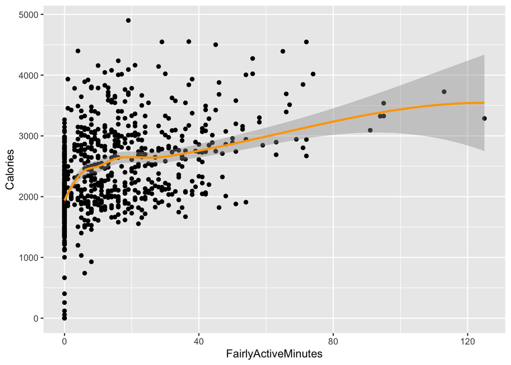

```r
df %>% filter(Id != 3977333714) %>%
  ggplot(aes(x=FairlyActiveMinutes, y=Calories)) +
  geom_point(color='black') +
  geom_smooth(formula=y~x, method='loess', color='orange')
```

Removing the outlier, tt now shows positive trend between `FairlyActiveMinutes` and `Calories` burnt - which makes more sense.

```r
# Slicing activity and calorie data
# Activity data includes 4 types of activities measured minutes
lm.calorie = df %>%
  filter(Id != 3977333714) %>%  # filtering the outlier user
  select(c(11:15)) %>%  # selecting only minutes and calories data
  drop_na() %>%
  lm(formula=Calories~.)

summary(lm.calorie)
```

```
Call:
lm(formula = Calories ~ ., data = .)

Residuals:
     Min       1Q   Median       3Q      Max
-2008.17  -391.24   -52.71   357.87  2563.07

Coefficients:
                      Estimate Std. Error t value Pr(>|t|)
(Intercept)          1.388e+03  8.812e+01  15.752  < 2e-16 ***
VeryActiveMinutes    1.175e+01  5.525e-01  21.259  < 2e-16 ***
FairlyActiveMinutes  9.141e+00  1.111e+00   8.227 6.65e-16 ***
LightlyActiveMinutes 1.696e+00  1.715e-01   9.893  < 2e-16 ***
SedentaryMinutes     2.542e-01  6.375e-02   3.987 7.23e-05 ***
---
Signif. codes:  0 '***' 0.001 '**' 0.01 '*' 0.05 '.' 0.1 ' ' 1

Residual standard error: 504.6 on 905 degrees of freedom
Multiple R-squared:  0.5017,    Adjusted R-squared:  0.4995
F-statistic: 227.8 on 4 and 905 DF,  p-value: < 2.2e-16
```

```r
lm.calorie$coefficients
```

```
         (Intercept)    VeryActiveMinutes  FairlyActiveMinutes
        1388.0994399           11.7463319            9.1409525
LightlyActiveMinutes     SedentaryMinutes
           1.6964838            0.2541881
```

The multivariate linear regression model reports the coefficients between activity minutes and calories. It makes sense that the more active the more calories burnt. It is interesting to see a big division between active vs non active when it comes to its effect on burning calories. It implies that to burn calories, just lightly or sedentary activities are not helpful. It is especially true for sedentary activity.

### Question3: How does steps and activities influence sleep time?

```r
# Create a new data frame with relevant features
df.temp = df %>% select(c(1, 3, 4, 11: ncol(df))) %>% drop_na()
```

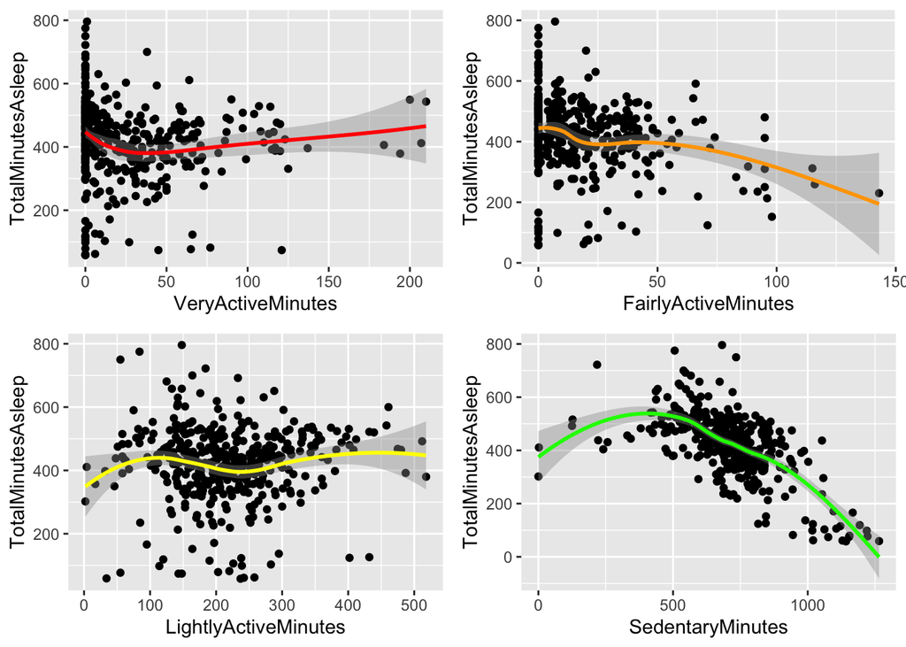

```r
# Plotting the relationship between each type of activity and time asleep

# f1. Total minutes asleep vs very active minutes
f1 = df.temp %>%
  ggplot(aes(x=VeryActiveMinutes, y=TotalMinutesAsleep)) + geom_point(color='black') +
  geom_smooth(formula=y~x, method='loess', color='red')

# f2. Total minutes asleep vs fairly active minutes
f2 = df.temp %>%
  ggplot(aes(x=FairlyActiveMinutes, y=TotalMinutesAsleep)) + geom_point(color='black') +
  geom_smooth(formula=y~x, method='loess', color='orange')

# f3. Total minutes asleep vs lightly active minutes
f3 = df.temp %>%
  ggplot(aes(x=LightlyActiveMinutes, y=TotalMinutesAsleep)) + geom_point(color='black') +
  geom_smooth(formula=y~x, method='loess', color='yellow')

# f4. Total minutes asleep vs sedentary minutes
f4 = df.temp %>%
  ggplot(aes(x=SedentaryMinutes, y=TotalMinutesAsleep)) + geom_point(color='black') +
  geom_smooth(formula=y~x, method='loess', color='green')

# Combine plots
grid.arrange(f1, f2, f3, f4, nrow=2)
```

It is not obvious to detect outliers from the plots. However, it appears that the correlation between type of activity (intensity) and sleep time is weak. Let’s see its statistical significant with linear regression.

```r
df.temp %>% select(c(4:7, 10)) %>%
  lm(formula=TotalMinutesAsleep~.) %>%
  summary()
```

```
Call:
lm(formula = TotalMinutesAsleep ~ ., data = .)

Residuals:
    Min      1Q  Median      3Q     Max
-524.89  -40.38   10.44   56.29  329.05

Coefficients:
                      Estimate Std. Error t value Pr(>|t|)
(Intercept)          827.32551   26.16450  31.620  < 2e-16 ***
VeryActiveMinutes     -0.15068    0.12967  -1.162    0.246
FairlyActiveMinutes   -1.39780    0.20475  -6.827 3.19e-11 ***
LightlyActiveMinutes  -0.21628    0.05314  -4.070 5.66e-05 ***
SedentaryMinutes      -0.46691    0.02713 -17.212  < 2e-16 ***
---
Signif. codes:  0 '***' 0.001 '**' 0.01 '*' 0.05 '.' 0.1 ' ' 1

Residual standard error: 87.72 on 405 degrees of freedom
Multiple R-squared:  0.4586,    Adjusted R-squared:  0.4533
F-statistic: 85.78 on 4 and 405 DF,  p-value: < 2.2e-16
```

Total minutes asleep can be partially explained by intensity of activity but it is negatively correlated. Let’s now extend this model with more predictor variables like TotalDistance and Steps.

```r
df.temp %>% select(c(2:7, 10)) %>%
  lm(formula=TotalMinutesAsleep~.) %>%
  summary()
```

```
Call:
lm(formula = TotalMinutesAsleep ~ ., data = .)

Residuals:
    Min      1Q  Median      3Q     Max
-522.49  -40.48    8.51   55.43  325.61

Coefficients:
                       Estimate Std. Error t value Pr(>|t|)
(Intercept)          824.800246  26.132481  31.562  < 2e-16 ***
TotalSteps            -0.008245   0.005849  -1.410    0.159
TotalDistance          6.395340   7.792706   0.821    0.412
VeryActiveMinutes      0.041944   0.182235   0.230    0.818
FairlyActiveMinutes   -1.097137   0.257477  -4.261 2.54e-05 ***
LightlyActiveMinutes  -0.117748   0.074983  -1.570    0.117
SedentaryMinutes      -0.463085   0.027129 -17.070  < 2e-16 ***
---
Signif. codes:  0 '***' 0.001 '**' 0.01 '*' 0.05 '.' 0.1 ' ' 1

Residual standard error: 87.5 on 403 degrees of freedom
Multiple R-squared:  0.464, Adjusted R-squared:  0.456
F-statistic: 58.15 on 6 and 403 DF,  p-value: < 2.2e-16
```

There is not much of improvement in the explainability of variables by adding steps and distance. Also, TotalSteps TotalDistance do not confidently show relationship with sleep time. Let’s now see if intensity can help reduce the time taken to fall asleep (TotalTimeInBed - TotalMinutesAsleep) - the assumption is that the smaller the time, the more quality one’s sleep is.

```r
df.temp %>%
  mutate(TimeTakenToSleep = TotalTimeInBed - TotalMinutesAsleep) %>%
  lm(formula=TimeTakenToSleep~VeryActiveMinutes+FairlyActiveMinutes+LightlyActiveMinutes+SedentaryMinutes) %>%
  summary()
```

```
Call:
lm(formula = TimeTakenToSleep ~ VeryActiveMinutes + FairlyActiveMinutes +
    LightlyActiveMinutes + SedentaryMinutes, data = .)

Residuals:
    Min      1Q  Median      3Q     Max
-87.077 -19.004  -6.411   9.116 305.276

Coefficients:
                      Estimate Std. Error t value Pr(>|t|)
(Intercept)          106.34770   12.38002   8.590  < 2e-16 ***
VeryActiveMinutes     -0.33051    0.06136  -5.387 1.22e-07 ***
FairlyActiveMinutes    0.81232    0.09688   8.385 8.51e-16 ***
LightlyActiveMinutes  -0.13532    0.02515  -5.382 1.25e-07 ***
SedentaryMinutes      -0.06181    0.01284  -4.816 2.07e-06 ***
---
Signif. codes:  0 '***' 0.001 '**' 0.01 '*' 0.05 '.' 0.1 ' ' 1

Residual standard error: 41.51 on 405 degrees of freedom
Multiple R-squared:  0.2182,    Adjusted R-squared:  0.2105
F-statistic: 28.26 on 4 and 405 DF,  p-value: < 2.2e-16
```

Given the R-squared, intensity of activities alone cannot fully explain the time taken to fall asleep.

### Question4: How does users use the device throughout days of week. Any particular patterns or differences?

```r
# Create day of week variable
df.temp = df
df.temp$DayOfWeek = weekdays(df.temp$Date)
```

```r
## Check normality of each variable

# colnames = colnames(df.clean.dow)
# for (i in 1:length(colnames)){
#   # Check if a variable is numeric
#   is_num = is.numeric(df.clean.dow[,i])
#   colname = colnames[i]
#   if (is_num) {
#     print(colname)
#     print(shapiro.test(df.clean.dow[,i]))
#   }
# }

# Refactored
# When p-value < 0.1, the hypothesis of normality will be rejected
# In other words, if the p value < 0.1, the distribution of a variable is not normal.

df.temp %>% select_if(is.numeric) %>%
  summarise_all(.funs = funs(pval = shapiro.test(.)$p.value))
```

| Id_pval | TotalSteps_pval | TotalDistance_pval | TrackerDistance_pval | LoggedActivitiesDistance_pval | VeryActiveDistance_pval | ModeratelyActiveDistance_pval | LightActiveDistance_pval | SedentaryActiveDistance_pval | VeryActiveMinutes_pval | FairlyActiveMinutes_pval | LightlyActiveMinutes_pval | SedentaryMinutes_pval | Calories_pval | TotalSleepRecords_pval | TotalMinutesAsleep_pval | TotalTimeInBed_pval |
| --- | --- | --- | --- | --- | --- | --- | --- | --- | --- | --- | --- | --- | --- | --- | --- | --- |
| 3.563714e-22 | 6.079134e-15 | 1.838656e-20 | 1.322684e-20 | 2.210693e-53 | 3.032743e-41 | 4.432301e-39 | 1.441079e-11 | 3.187171e-52 | 5.713411e-38 | 1.165949e-37 | 3.479477e-11 | 4.867194e-17 | 4.336312e-13 | 3.189719e-35 | 2.480085e-10 | 1.607801e-14 |

According to Shapiro-Wilk’s test, none of the numeric features (i.e. distance, step, activity distance/minute, sleep, etc) are normal. So the aggregation through summary statistics should be carefully performed For example, mean of a feature is not relevent - let’s use median instead.

```r
# Without sleep data that has missing values
df.temp.stats = df.temp %>%
  select(c(3:4, 11:ncol(df.temp)-4)) %>%
  aggregate(by=list(c(df.temp$DayOfWeek)), median)

df.temp.stats = rename(df.temp.stats, DayOfWeek = Group.1)
df.temp.stats$DayOfWeek = factor(df.temp.stats$DayOfWeek,
                                 levels= c("Sunday", "Monday", "Tuesday", "Wednesday", "Thursday", "Friday", "Saturday"))
```

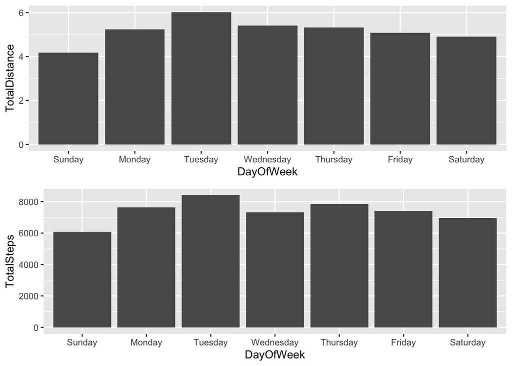

```r
# Plotting the results
f1 = df.temp.stats %>% ggplot(aes(x=DayOfWeek, y=TotalDistance)) + geom_bar(stat = "identity")
f2 = df.temp.stats %>% ggplot(aes(x=DayOfWeek, y=TotalSteps)) + geom_bar(stat = "identity")
grid.arrange(f1, f2, ncol=1)
```

The level of activities peaks on Tuesday and the lowest on Sunday.

## 4. Further Analysis through Clustering

**Methodology:** Hierarchical clustering will firstly be performed and a dendrogram will be plotted to intuitively evaluate the number of clusters needed. KMeans clustering will be followed with the same number of clustering assigned to determine **k** centeroids to be used.

### Preprocessing

Create a new data frame filtering out unnecessary / duplicated variables. To remove

1. The 4 variables related to distances by intensities - to use aggregated `TotalDistance` and the other 4 `ActiveMinutes` variables.
2. `Date` variable as the new data frame will represent numeric variables grouped by individual ids
3. `TrackerDistance` and `LoggedActivitiesDistance` are redundant for our analysis.
4. All sleep data will be dropped due to missing values

Now aggregate the numeric variables by `Id`. As we observed that all the numeric features are skewed. Therefore, we will represent **median** values. There are 9 Ids that do not have sleep data at all so filling NA values is not possible - as the original `df.sleep` data had contain records from 24 ids. Let’s firstly conduct a clustering without sleep data, which means we will exclude sleep variables so all 33 ids can be used. As it will mostly contains activity data, save it as `df.grouped.activity`

```r
# Remove unncessary cols and
# Transform the clustering dataframe - 33 unique ids excluding sleep variables
df.clustering  = df %>% select(-c(2, 5:10, 16:ncol(df))) %>%
  aggregate(by=list(df$Id), median)

# Inspect the dataset
dim(df.clustering) # should have 33 unique ids
```

```
[1] 33  9
```

```r
sum(!complete.cases(df.clustering)) # no missing values
```

```
[1] 0
```

Clustering algorithms performs bad on data with different scales so standardising the data is important.

```r
# Drop id columns unnecessary columns
# and re-scaling
df.clustering.scaled = df.clustering %>% select(!c(1:2)) %>% scale()
head(df.clustering.scaled)
```

```
     TotalSteps TotalDistance VeryActiveMinutes FairlyActiveMinutes
[1,]  1.1966808     0.9503990         0.7724900           0.7859025
[2,] -0.8836117    -0.9381284        -0.6831110          -0.8704366
[3,] -0.2078536    -0.1561873        -0.5298899           0.2192602
[4,] -1.3385247    -1.3360805        -0.6831110          -0.8704366
[5,] -1.8687055    -1.8143212        -0.6831110          -0.8704366
[6,]  1.0291080     1.0411601         0.6958795           0.6115510
     LightlyActiveMinutes SedentaryMinutes   Calories
[1,]            0.2332554       -0.7751293 -0.7972225
[2,]           -0.5034985        1.0922487 -1.4698434
[3,]           -0.4210260        0.6768524  0.8182388
[4,]           -1.1962671        1.1417914 -1.2791002
[5,]           -2.0209916        1.5686206 -0.3571746
[6,]            0.8270571        0.4215170  0.3606223
```

### Hierarchical clustering (agglomerative - bottom up)

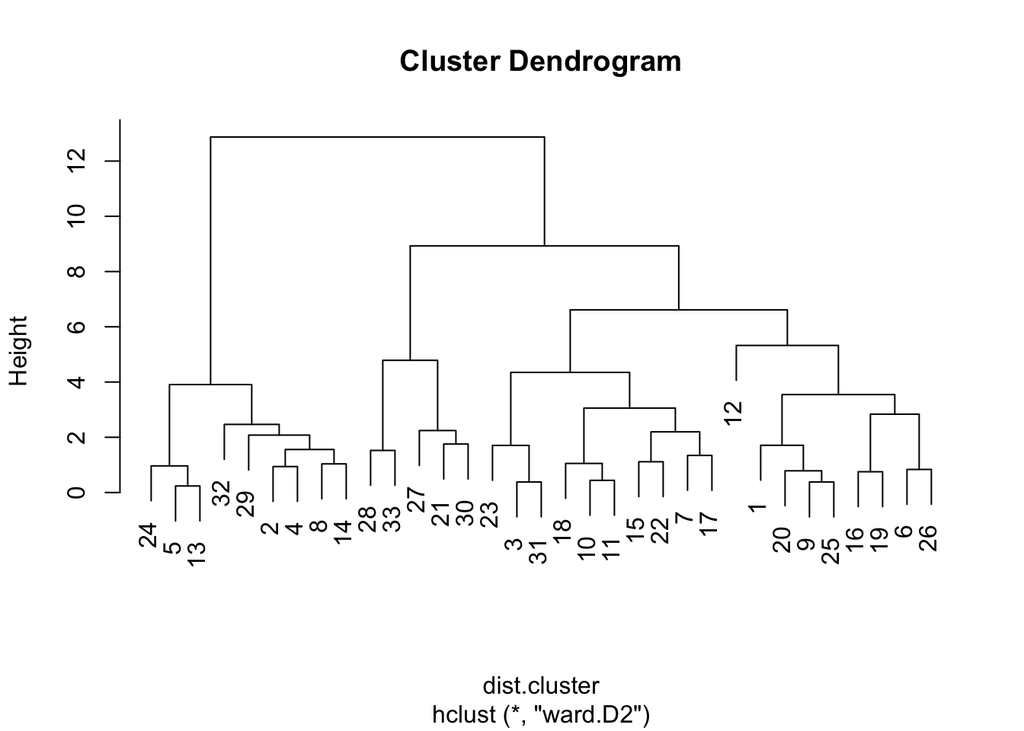

```r
# 1. Compute distances across between variables
dist.cluster = dist(df.clustering.scaled, method='euclidean')

# 2. Clustering based on the computed distance
tree = hclust(dist.cluster, method ='ward.D2')

# 3. Plot a dendrogram
plot(tree)
```

The height represents the degree of distance between clusters. Intuitively base don the visualization, grouping with 5 clusters are reasonable - note that there is an potential outlier (labled as 12).

```r
# Cut trees with 5 clusters
seg = cutree(tree, k=5)

# Attaching segment information to the data frames
df.clustering$SegHclust = seg
table(df.clustering$SegHclust) # Cluster 4 has one record which is be a potential outlier.
```

```
 1  2  3  4  5
 8  9 10  1  5
```

```r
# Gain insights over the outlier
df.clustering[df.clustering$SegHclust == 4, 'Id'] # Id = 3977333714
```

```
[1] 3977333714
```

Remember that the #Id 3977333714 is the user that was classified as an outlier in the previous descriptive analysis. This user spent more minutes staying fairly active but did not burn comparatively enough calories than others - the user lacked sleeps as well. By removing this user, the relationship activity and calories was clearer. By keeping this outlier information in mind, let’s review the segmentation report as below:

```r
# Group by segments and print the results
df.clustering %>%
  mutate(TotalMinutes=VeryActiveMinutes+FairlyActiveMinutes+LightlyActiveMinutes+SedentaryMinutes) %>%
  select(!c(1:2)) %>%
  aggregate(by=list(df.clustering$SegHclust), median)
```

| Group.1 | TotalSteps | TotalDistance | VeryActiveMinutes | FairlyActiveMinutes | LightlyActiveMinutes | SedentaryMinutes | Calories | SegHclust | TotalMinutes |
| --- | --- | --- | --- | --- | --- | --- | --- | --- | --- |
| 1 | 10338 | 7.440 | 18.5 | 15.5 | 253.5 | 768.00 | 2300.25 | 1 | 1041.5 |
| 2 | 2237 | 1.480 | 0.0 | 0.0 | 87.0 | 1288.00 | 1934.00 | 2 | 1422.0 |
| 3 | 6917 | 4.880 | 1.5 | 3.5 | 270.5 | 1081.75 | 2185.50 | 3 | 1382.5 |
| 4 | 11604 | 7.815 | 14.5 | 56.5 | 176.0 | 712.50 | 1572.00 | 4 | 959.5 |
| 5 | 10091 | 6.810 | 68.0 | 10.0 | 158.0 | 761.00 | 3389.50 | 5 | 983.5 |

Each segment is expected to have a distinctive property from the others. Let’s take a closer look:

Let’s map the description onto the cluster numbers.

```r
# Instantiate a column to map
df.clustering$SegHclustLabel = NA

# Map with number in 'SegHclust' with labels
df.clustering$SegHclustLabel[which(df.clustering$SegHclust == 1)] = 'Active'
df.clustering$SegHclustLabel[which(df.clustering$SegHclust == 2)] = 'Inactive'
df.clustering$SegHclustLabel[which(df.clustering$SegHclust == 3)] = 'Light'
df.clustering$SegHclustLabel[which(df.clustering$SegHclust == 4)] = 'Outlier'
df.clustering$SegHclustLabel[which(df.clustering$SegHclust == 5)] = 'Power'
```

As there are many variables, to represent the relationship in 2D plot, let’s use two correlated variables: total steps and calories. The grouping is fairly distinctive but with noise, attributed to the low sample size (33 Ids only).

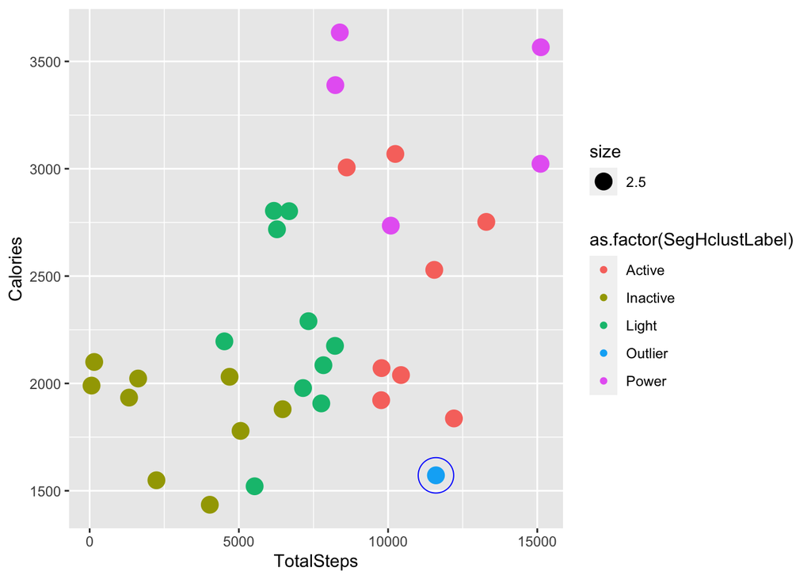

```r
# Plotting
df.clustering %>%
  ggplot(aes(x=TotalSteps, y=Calories, color=as.factor(SegHclustLabel), size = 2.5)) + geom_point() +
  geom_point(data=df.clustering %>% filter(Id==3977333714), pch=21, size=10, colour='blue')
```

### Kmeans clustering

```r
# Set a seed and run kmean clustering with 5 centeroids
set.seed(20)
kmclust = df.clustering.scaled %>%  kmeans(centers=5)

# Assign clusters to each records
df.temp = df.clustering
df.temp$SegKmeans = kmclust$cluster

# Aggregate the record by SegKmeans
# Note that the number assigned to each cluster is different from hierarchical cluster
df.temp %>% select(!c(1:2, 10:11)) %>% # hide unnecessary columns
  aggregate(by=list(df.temp$SegKmeans), median)
```

| Group.1 | TotalSteps | TotalDistance | VeryActiveMinutes | FairlyActiveMinutes | LightlyActiveMinutes | SedentaryMinutes | Calories | SegKmeans |
| --- | --- | --- | --- | --- | --- | --- | --- | --- |
| 1 | 6225.50 | 4.5100 | 1.00 | 5.0 | 159.75 | 1228.0 | 2374.50 | 1 |
| 2 | 10433.00 | 7.8150 | 18.00 | 16.0 | 253.00 | 761.0 | 2529.00 | 2 |
| 3 | 11745.00 | 8.6600 | 77.25 | 9.0 | 158.25 | 928.0 | 3477.75 | 3 |
| 4 | 7547.00 | 5.2100 | 1.50 | 3.5 | 285.00 | 740.0 | 2031.75 | 4 |
| 5 | 1472.25 | 1.0025 | 0.00 | 0.0 | 48.50 | 1348.5 | 1962.00 | 5 |

Let’s look at the plot first to see the grouping more clearly.

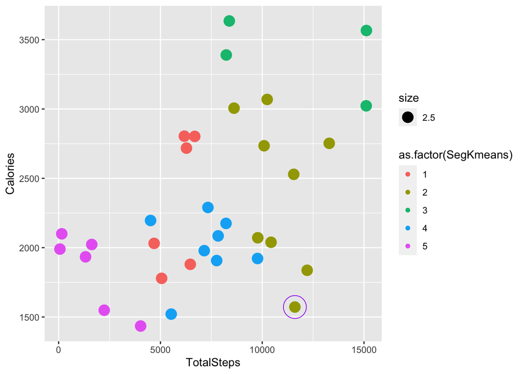

```r
# Plotting Kmeans clusters
df.temp %>%
  ggplot(aes(x=TotalSteps, y=Calories, color=as.factor(SegKmeans), size=2.5)) + geom_point() +
  geom_point(data=df.clustering %>% filter(Id==3977333714), pch=21, size=10, colour='purple') # outlier
```

Let’s try with 4 centerfolds, hoping to get more distinctive clusters.

```r
kmclust2 = df.clustering.scaled %>% kmeans(centers=4)

# Assign clusters to each records
df.temp = df.clustering
df.temp$SegKmeans = kmclust2$cluster

# Aggregate the record by SegKmeans
# Note that the number assigned to each cluster is different from hierarchical cluster
df.temp %>% select(!c(1:2, 10:11)) %>% # hide unnecessary columns
  aggregate(by=list(df.temp$SegKmeans), median)
```

| Group.1 | TotalSteps | TotalDistance | VeryActiveMinutes | FairlyActiveMinutes | LightlyActiveMinutes | SedentaryMinutes | Calories | SegKmeans |
| --- | --- | --- | --- | --- | --- | --- | --- | --- |
| 1 | 10338.00 | 7.4025 | 18.50 | 16 | 246.00 | 749.5 | 2300.25 | 1 |
| 2 | 6683.50 | 4.8600 | 1.00 | 2 | 258.00 | 1087.0 | 2175.00 | 2 |
| 3 | 11745.00 | 8.6600 | 77.25 | 9 | 158.25 | 928.0 | 3477.75 | 3 |
| 4 | 1930.75 | 1.3225 | 0.00 | 0 | 83.50 | 1294.5 | 1962.00 | 4 |

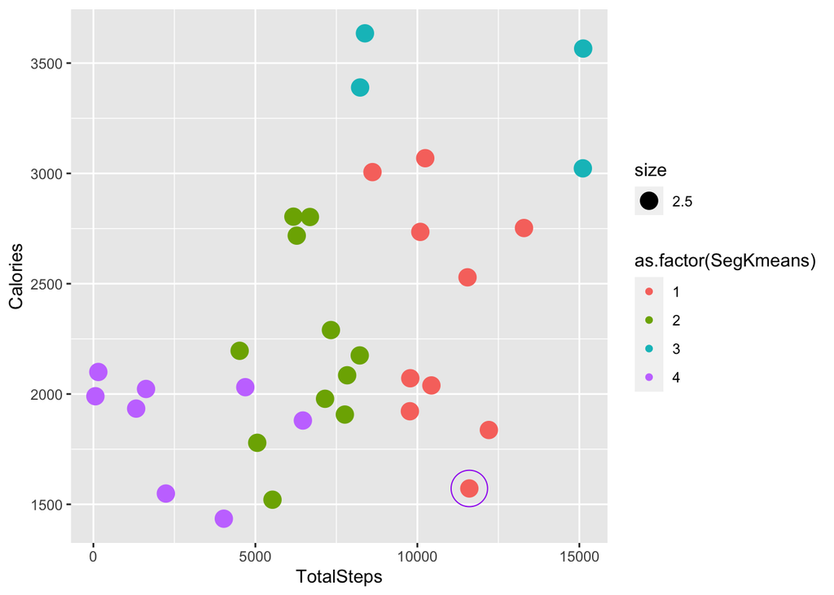

```r
# Plotting Kmeans clusters
df.temp %>%
  ggplot(aes(x=TotalSteps, y=Calories, color=as.factor(SegKmeans), size=2.5)) + geom_point() +
  geom_point(data=df.temp %>% filter(Id==3977333714), pch=21, size=10, colour='purple')
```

Kmeans clustering has been performed twice with 5 and 4 centroids each. However, we are not sure how many centroids are ideal. Let’s perform a silhouette test to see if we can find the optimal k (# centeroids).

The below code is inspired by a [post on medium](https://medium.com/codesmart/r-series-k-means-clustering-silhouette-794774b46586).

```r
# Install and load packages
# install.packages('cluster')
require('cluster')
```

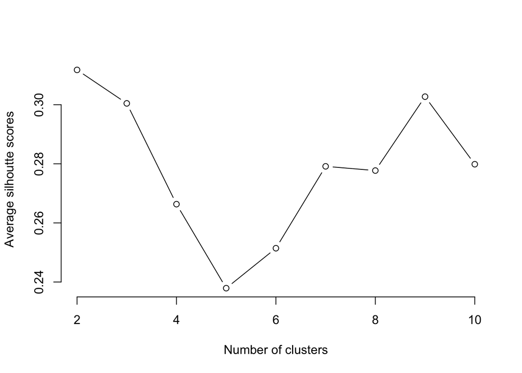

```r
# Function for silhouette test on 'df.grouped.activity.scaled'
silhouette_test = function(k) {
  km = kmeans(df.clustering.scaled, centers=k)
  ss = silhouette(km$cluster, dist(df.clustering.scaled))
  mean(ss[, 3])
}

k = 2:10
avg_sil = sapply(k, silhouette_test)
plot(k, type='b', avg_sil, xlab='Number of clusters', ylab='Average silhoutte scores', frame=FALSE)
```

The values from Silhouette scores range from -1 to 1 where a high value indicates that the data point is well matched to its own cluster. It looks that using 2 clusters looks good but practically speaking then clustering is not useful. Also, too many clusters given the small sample size (33 ids) are not equally useful as each cluster then will be characterized from a few data points only. In a practical point of view, grouping by 4-5 clusters still make sense.

For the particular dataset, between the two clustering methods, hierarchical clustering provides clearer representation of clusters as it successfully classifies an outlier. More data examples and features (including demographics for example) may be more helpful to divide groups.